# Analyzing Individual BGG Users

Phil Henrickson

2021-12-21

# **camerinjohnston’s** BoardGameGeek Collection

This notebook contains a set of analyses for the selected user’s boardgamegeek collection. The bulk of the analysis is focused on building a user-specific predictive model to predict the games that camerinjohnston is likely to own. This enables to ask questions like, based on the games the user currently owns, what games are a good fit for their collection? What upcoming games are they likely to purchase?

This analysis is based on data from BoardGameGeek that was last updated on **2021-12-06.**

# 1 Collection Overview

We can look at a basic description of the number of games that the user owns, has rated, has previously owned, etc.

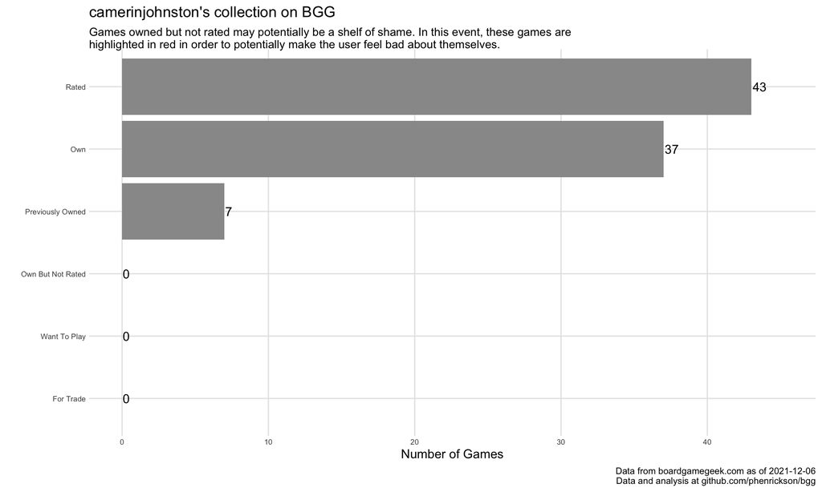

What years has the user owned/rated games from? While we can’t see when a user added or removed a game from their collection, we can look at their collection by the years in which their games were published.

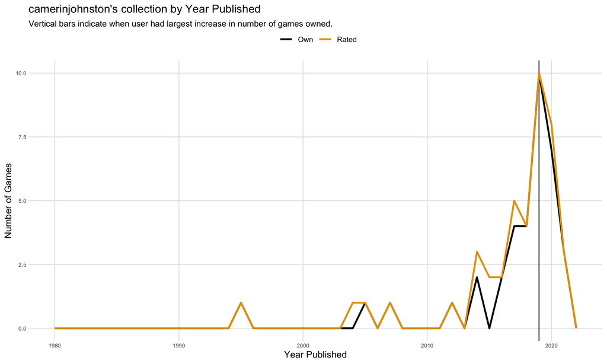

## 1.1 What types of games does camerinjohnston own?

We can look at the most frequent types of categories, mechanics, designers, and artists that appear in a user’s collection.

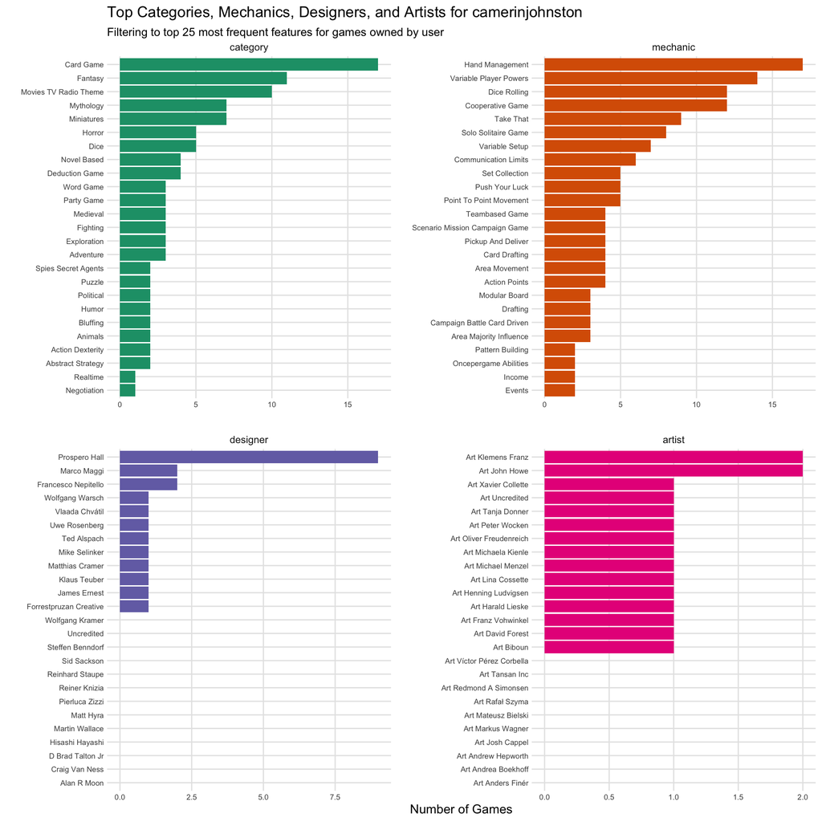

# 2 Modeling **camerinjohnston’s** Collection

| username | dataset | period | games_owned | games_rated | games_played |
| --- | --- | --- | --- | --- | --- |
| camerinjohnston | training | published before 2020 | 27 | 32 | 33 |
| camerinjohnston | test | published 2020 or later | 10 | 11 | 12 |

There are two main (binary) outcomes we will be modeling for the user.

The first, **own** refers to whether the user currently lists a game as owned in their collection. The second, **played** refers to whether the user currently owns, has rated, or previously owned a game. This means the latter will generally have a larger list of games, but may still be a useful category to examine for people who play lots of games without necessarily owning them.

We will train predictive models to learn the probability that the user will own or play individual games based on their features.

## 2.1 Coefficients for camerinjohnston

We can examine coefficients from the trained modes, which are penalized logistic regressions fit to our two main outcomes. Positive values indicate that a feature increases a user’s probabilility of owning/rating a game, while negative values indicate a feature decreases the probability.

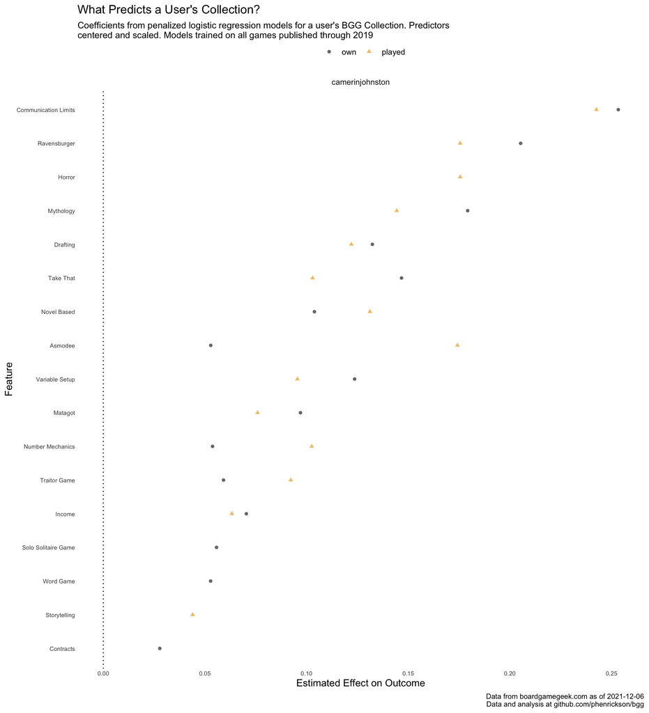

## 2.2 Visualizing Predictors for camerinjohnston’s Collection

Why did the model identify these features? We can make density plots of the important features for predicting whether the user owned a game. Blue indicates the density for games owned by the user, while grey indicates the density for games not owned by the user.

[figure not shown]

Binary predictors can be difficult to see with this visualization, so we can also directly examine the percentage of games in a user’s collection with a predictor vs the percentage of all games with that predictor.

| username | Feature | % of Games with Feature In_Collection | % of Games with Feature All_Games | Ratio |
| --- | --- | --- | --- | --- |
| camerinjohnston | Communication Limits | 18.5% | 0.9% | 19.6 |
| camerinjohnston | Traitor Game | 7.4% | 0.7% | 11.2 |
| camerinjohnston | Drafting | 11.1% | 1.0% | 10.8 |
| camerinjohnston | Income | 7.4% | 0.7% | 10.3 |
| camerinjohnston | Mythology | 18.5% | 2.2% | 8.4 |
| camerinjohnston | Variable Setup | 14.8% | 1.9% | 8.0 |
| camerinjohnston | Matagot | 11.1% | 1.5% | 7.3 |
| camerinjohnston | Contracts | 7.4% | 1.0% | 7.2 |
| camerinjohnston | Word Game | 11.1% | 1.7% | 6.4 |
| camerinjohnston | Ravensburger | 18.5% | 3.2% | 5.8 |
| camerinjohnston | Novel Based | 14.8% | 2.8% | 5.3 |
| camerinjohnston | Asmodee | 22.2% | 5.4% | 4.1 |
| camerinjohnston | Take That | 25.9% | 6.6% | 3.9 |
| camerinjohnston | Solo Solitaire Game | 22.2% | 5.9% | 3.8 |
| camerinjohnston | Horror | 14.8% | 3.9% | 3.8 |
| camerinjohnston | Movies TV Radio Theme | 14.8% | 3.9% | 3.8 |
| camerinjohnston | Cooperative Game | 29.6% | 8.5% | 3.5 |
| camerinjohnston | Puzzle | 7.4% | 3.4% | 2.2 |
| camerinjohnston | Negotiation | 3.7% | 3.6% | 1.0 |
| camerinjohnston | Party Game | 7.4% | 8.5% | 0.9 |
| camerinjohnston | Action Dexterity | 3.7% | 4.8% | 0.8 |
| camerinjohnston | Trivia | 0.0% | 1.9% | 0.0 |
| camerinjohnston | City Building | 0.0% | 4.3% | 0.0 |
| camerinjohnston | Racing | 0.0% | 2.8% | 0.0 |
| camerinjohnston | Mafia | 0.0% | 0.7% | 0.0 |

# 3 Assess Model’s Performance on Training Set

Before predicting games in upcoming years, we can examine how well the model did and what games it liked in the training set. In this case, we used resampling techniques (cross validation) to ensure that the model had not seen a game before making its predictions.

## 3.1 Separation Plot

An easy way to examine the performance of classification model is to view a separation plot. We plot the predicted probabilities from the model for every game (from resampling) from lowest to highest. We then overlay a blue line for any game that the user does own. A good classifier is one that is able to *separate* the blue (games owned by the user) from the white (games not owned by the user), with most of the blue occurring at the highest probabilities (right side of the chart).

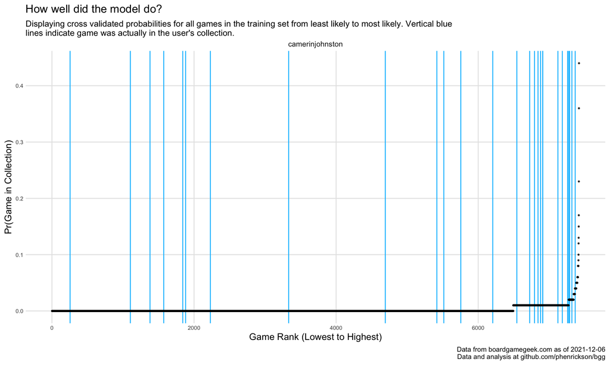

## 3.2 Top Games for **camerinjohnston** from Training Set

We can display this information in table form, displaying the 100 games with the highest probability of ownership, adding a blue line when the user does own the game.

| username | yearpublished | game_id | name | pred_played | pred_own | actual_played | actual_own |
| --- | --- | --- | --- | --- | --- | --- | --- |
| camerinjohnston | 2014 | 156129 | Deception: Murder in Hong Kong | 0.27 | 0.44 | 0 | 0 |
| camerinjohnston | 2005 | 15062 | Shadows over Camelot | 0.30 | 0.36 | 0 | 0 |
| camerinjohnston | 2014 | 166384 | Spyfall | 0.10 | 0.23 | 0 | 0 |
| camerinjohnston | 2018 | 244711 | Newton | 0.25 | 0.17 | 0 | 0 |
| camerinjohnston | 2018 | 205896 | Rising Sun | 0.26 | 0.15 | 0 | 0 |
| camerinjohnston | 2007 | 29937 | König von Siam | 0.04 | 0.13 | 0 | 0 |
| camerinjohnston | 2015 | 172996 | The King Is Dead | 0.16 | 0.12 | 0 | 0 |
| camerinjohnston | 2014 | 146886 | La Granja | 0.08 | 0.10 | 0 | 0 |
| camerinjohnston | 2019 | 263155 | One Key | 0.13 | 0.09 | 0 | 0 |
| camerinjohnston | 2019 | 283863 | The Magnificent | 0.01 | 0.08 | 0 | 0 |
| camerinjohnston | 2018 | 225694 | Decrypto | 0.12 | 0.08 | 0 | 0 |
| camerinjohnston | 2019 | 242529 | Medium | 0.02 | 0.08 | 0 | 0 |
| camerinjohnston | 2016 | 205158 | Codenames: Deep Undercover | 0.09 | 0.08 | 0 | 0 |
| camerinjohnston | 2018 | 254640 | Just One | 0.06 | 0.08 | 0 | 0 |
| camerinjohnston | 1989 | 1111 | Taboo | 0.05 | 0.08 | 0 | 0 |
| camerinjohnston | 2008 | 38506 | Witch of Salem | 0.02 | 0.06 | 0 | 0 |
| camerinjohnston | 1999 | 1353 | Time's Up! | 0.03 | 0.06 | 0 | 0 |
| camerinjohnston | 2015 | 178900 | Codenames | 0.08 | 0.06 | 0 | 0 |
| camerinjohnston | 2007 | 33495 | Time's Up! Édition purple | 0.09 | 0.06 | 0 | 0 |
| camerinjohnston | 2013 | 147151 | Concept | 0.09 | 0.06 | 0 | 0 |
| camerinjohnston | 2008 | 38713 | Time's Up! Edición Amarilla | 0.06 | 0.06 | 0 | 0 |
| camerinjohnston | 2016 | 205322 | The Oregon Trail Card Game | 0.08 | 0.06 | 0 | 0 |
| camerinjohnston | 2016 | 198454 | When I Dream | 0.12 | 0.06 | 0 | 0 |
| camerinjohnston | 2017 | 214293 | Mountains of Madness | 0.33 | 0.06 | 0 | 0 |
| camerinjohnston | 2018 | 249821 | Codenames: Harry Potter | 0.05 | 0.05 | 0 | 0 |
| camerinjohnston | 2019 | 269146 | Yōkai | 0.08 | 0.05 | 0 | 0 |
| camerinjohnston | 2018 | 258444 | Gingerbread House | 0.03 | 0.05 | 0 | 0 |
| camerinjohnston | 2019 | 251247 | Barrage | 0.01 | 0.05 | 0 | 0 |
| camerinjohnston | 2016 | 217353 | Assembly | 0.06 | 0.05 | 0 | 0 |
| camerinjohnston | 2014 | 164265 | Witness | 0.07 | 0.05 | 0 | 0 |

[output cut: 70 more lines]

We can also more formally assess how well the model did in resampling by looking at the area under the receiver operating characteristic. A perfect model would receive a score of 1, while a model that cannot predict the outcome will default to a score of 0.5. The extent to which something is a *good* score depends on the setting, but generally anything in the .8 to .9 range is very good while the .7 to .8 range is perfectly acceptable.

| username | outcome_type | .metric | .estimator | .estimate |
| --- | --- | --- | --- | --- |
| camerinjohnston | own | roc_auc | binary | 0.752 |
| camerinjohnston | played | roc_auc | binary | 0.738 |

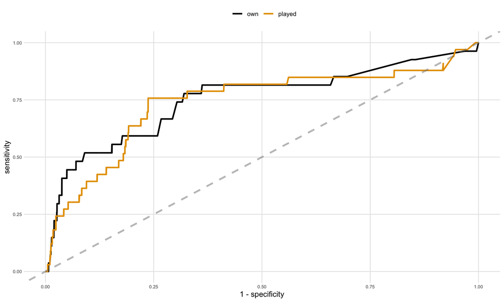

Another way to think about the model performance is to view its lift, or its ability to detect the positive outcomes over that of a null model. High lift indicates the model can much more quickly find all of the positive outcomes (in this case, games owned or played by the user), while a model with no lift is no better than random guessing.

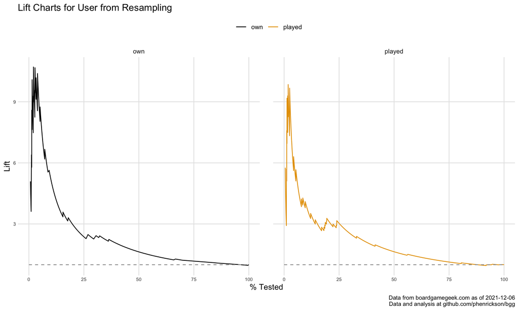

## 3.3 Most and Least Likely Games

What games does the model think camerinjohnston is **most likely to own** that are **not** in their collection?

| username | yearpublished | game_id | name | pred_own | actual_own |
| --- | --- | --- | --- | --- | --- |
| camerinjohnston | 2014 | 156129 | Deception: Murder in Hong Kong | 0.44 | 0 |
| camerinjohnston | 2005 | 15062 | Shadows over Camelot | 0.36 | 0 |
| camerinjohnston | 2014 | 166384 | Spyfall | 0.23 | 0 |
| camerinjohnston | 2018 | 244711 | Newton | 0.17 | 0 |
| camerinjohnston | 2018 | 205896 | Rising Sun | 0.15 | 0 |

What games does the model think camerinjohnston is **least likely to own** that **are** in their collection?

| username | yearpublished | game_id | name | pred_own | actual_own |
| --- | --- | --- | --- | --- | --- |
| camerinjohnston | 2019 | 274364 | Watergate | 0 | 1 |
| camerinjohnston | 1948 | 320 | Scrabble | 0 | 1 |
| camerinjohnston | 2012 | 115746 | War of the Ring: Second Edition | 0 | 1 |
| camerinjohnston | 2005 | 12692 | Gloom | 0 | 1 |
| camerinjohnston | 2018 | 212402 | The Grimm Forest | 0 | 1 |

## 3.4 Top Games by Year

Top 25 games most likely to be owned by the user in each year, highlighting in blue the games that the user has owned/played.

| rank | 2011 | 2012 | 2013 | 2014 | 2015 | 2016 | 2017 | 2018 | 2019 |
| --- | --- | --- | --- | --- | --- | --- | --- | --- | --- |
| 1 | Tragedy Looper | Kemet | Concept | Deception: Murder in Hong Kong | The King Is Dead | Codenames: Deep Undercover | Mountains of Madness | Newton | One Key |
| 2 | Elder Sign | The Manhattan Project | The Ravens of Thri Sahashri | Spyfall | Codenames | The Oregon Trail Card Game | Codenames: Marvel | Rising Sun | The Magnificent |
| 3 | Sekigahara: The Unification of Japan | Archipelago | Tajemnicze Domostwo | La Granja | Mysterium | When I Dream | Gloomhaven | Decrypto | Medium |
| 4 | Omen: A Reign of War | Neuroshima: Convoy | Room 25 | Witness | ...and then, we held hands. | Assembly | Codenames: Disney – Family Edition | Just One | Yōkai |
| 5 | The Castles of Burgundy | Nautilus | Smash Up: The Obligatory Cthulhu Set | Imperial Settlers | The Grizzled | Terraforming Mars | Muse | Codenames: Harry Potter | Barrage |
| 6 | Village | In Magnificent Style: Pickett's Charge at Gettysburg | Bomb Squad | Five Tribes | One Night Ultimate Werewolf: Daybreak | Inis | Fog of Love | Gingerbread House | Sherlock: Entre tumbas |
| 7 | Space Empires: 4X | Venture Forth | Smash Up: Awesome Level 9000 | Mythotopia | Viticulture Essential Edition | Covalence: A Molecule Building Game | Gaia Project | Sherlock: The Tomb of the Archaeologist | Sherlock: Don's Legacy |
| 8 | The Secret of Monte Cristo | Wiz-War (Eighth Edition) | Le Fantôme de l'Opéra | The Lord of the Ice Garden | Nevermore | Beyond Baker Street | Codenames: Duet | Sherlock: 13 Hostages | Letter Jam |
| 9 | Discworld: Ankh-Morpork | Seasons | The Witches: A Discworld Game | Machina Arcana | The Game | Control | Arkham Noir: Case #1 – The Witch Cult Murders | Sherlock: Propagation | Pictures |
| 10 | Artus | Tahiti | Firefly: The Game | Sheep & Thief | The Dwarves: The Duel | The Oracle of Delphi | Fate of the Elder Gods | Sherlock: Last Call | Tapestry |
| 11 | Octopus's Garden | City of Gears | Castle Dice | Marrying Mr. Darcy | Raptor | Codenames: Pictures | Yamataï | Everdell | Unmatched: Battle of Legends, Volume One |
| 12 | BITS | Merchant of Venus (Second Edition) | Sanssouci | Port Royal | Matcha | Kreus | Clans of Caledonia | Nemesis | Fiesta de los Muertos |
| 13 | Casa Grande | Kairo | The Great Heartland Hauling Co. | Dead of Winter: A Crossroads Game | Coffee Roaster | Okey Dokey | Dinosaur Island | Root | Wingspan |
| 14 | Kingdom Builder | Smash Up | Jungle Ascent | Heroes of Normandie | Albion's Legacy | Smash Up: It's Your Fault! | Magic Maze | The Grizzled: Armistice Edition | Chai |
| 15 | Schnappt Hubi! | Mythic Battles | The Lord of the Rings Dice Building Game | The Battle of Five Armies | Haspelknecht | 13 Days: The Cuban Missile Crisis | Betrayal at Baldur's Gate | Fuji | Yukon Airways |
| 16 | Scotland Yard: Hunting Mister X | Ark & Noah | Enclave: Zakon Krańca Świata | Smash Up: Science Fiction Double Feature | Blood Rage | Smash Up: Cease and Desist | 13 Minutes: The Cuban Missile Crisis, 1962 | Brass: Birmingham | Orléans Stories |
| 17 | Ultimate Warriorz | Among the Stars | Bugs in the Kitchen | Pagoda | Ylandyss | Thunder & Lightning | Konja | Who Goes There? | A War of Whispers |
| 18 | Yggdrasil | Indigo | Cappuccino | Smash Up: Monster Smash | The Pursuit of Happiness | Fight for Olympus | Smash Up: What Were We Thinking? | Muse: Awakenings | Era: Medieval Age |
| 19 | 011 | The Lord of the Rings: The Battle for Middle-Earth | Eldritch Horror | Patchwork | Kingdom Death: Monster | Roll Player | Iron Curtain | First Contact | Machina Arcana (Second/Third Edition) |
| 20 | Eclipse | Asgard | Complots | Fields of Arle | X-Men: Mutant Revolution | Yokohama | Mythic Battles: Pantheon | Arkham Horror (Third Edition) | Maracaibo |
| 21 | Dungeon Fighter | Lucky Numbers | Hannin Wa Odoru | Sons of Anarchy: Men of Mayhem | Runebound (Third Edition) | The Arrival | Pulsar 2849 | Disney Villainous | Amul |
| 22 | Flash Point: Fire Rescue | Kill the Overlord | Ultimate Werewolf: Inquisition | Deus | Journey: Wrath of Demons | Meduris: Der Ruf der Götter | Pendragon: The Fall of Roman Britain | A Song of Ice & Fire: Tabletop Miniatures Game – Stark vs Lannister Starter Set | Similo |
| 23 | Cover Your Assets | Shadows over Camelot: The Card Game | Caverna: The Cave Farmers | Orléans | Harbour | Hit Z Road | Valletta | Kero | GROWL |
| 24 | Guards! Guards! A Discworld Boardgame | One Night Werewolf | Zombicide Season 2: Prison Outbreak | Ancient Terrible Things | Elysium | Aeon's End | A Game of Thrones: Catan – Brotherhood of the Watch | Liberation | Yggdrasil Chronicles |
| 25 | Olympos | Atlantis Rising | Impulse | Arcadia Quest | Argonauts | Harry Potter: Hogwarts Battle | Bunny Kingdom | Choose Your Own Adventure: House of Danger | The Lord of the Rings: Journeys in Middle-Earth |

### 3.4.1 Interactive Table for Resampling

Interactive table for predictions from resampling.

|  | username | yearpublished | rank | game_id | name | pred_played | pred_own | actual_played | actual_own |
| --- | --- | --- | --- | --- | --- | --- | --- | --- | --- |
| 1 | camerinjohnston | 1900 | 68 | 21389 | Happy Families | 0 | 0.03 | 0 | 0 |
| 2 | camerinjohnston | 1900 | 123 | 45 | Perudo | 0.01 | 0.02 | 0 | 0 |
| 3 | camerinjohnston | 1900 | 125 | 2136 | Pachisi | 0.01 | 0.02 | 0 | 0 |
| 4 | camerinjohnston | 1900 | 130 | 10799 | Old Maid | 0.01 | 0.02 | 0 | 0 |
| 5 | camerinjohnston | 1900 | 186 | 1602 | The Royal Game of Ur | 0 | 0.01 | 0 | 0 |
| 6 | camerinjohnston | 1900 | 187 | 2397 | Backgammon | 0.01 | 0.01 | 0 | 0 |
| 7 | camerinjohnston | 1900 | 214 | 3886 | Nine Men's Morris | 0.01 | 0.01 | 0 | 0 |
| 8 | camerinjohnston | 1900 | 230 | 10400 | Patience | 0 | 0.01 | 0 | 0 |
| 9 | camerinjohnston | 1900 | 577 | 17003 | Snap | 0.02 | 0.01 | 0 | 0 |
| 10 | camerinjohnston | 1900 | 690 | 2386 | Chinese Checkers | 0.01 | 0.01 | 0 | 0 |

[output cut: 7409 more lines]

# 4 Validating the Model on 2020

How well did a model trained on a user’s collection through 2019 perform in predicting games for the user from 2020?

| username | outcome_type | yearpublished | .metric | .estimator | .estimate |
| --- | --- | --- | --- | --- | --- |
| camerinjohnston | own | 2020 | roc_auc | binary | 0.628 |
| camerinjohnston | played | 2020 | roc_auc | binary | 0.633 |

Table of top 25 games from 2020, highlighting games that the user owns.

| username | yearpublished | game_id | name | pred_own | pred_played | actual_own | actual_played |
| --- | --- | --- | --- | --- | --- | --- | --- |
| camerinjohnston | 2020 | 297030 | Tekhenu: Obelisk of the Sun | 0.14 | 0.09 | 0 | 0 |
| camerinjohnston | 2020 | 302193 | Wonder Woman: Challenge of the Amazons | 0.09 | 0.08 | 0 | 0 |
| camerinjohnston | 2020 | 307002 | Regicide | 0.07 | 0.06 | 0 | 0 |
| camerinjohnston | 2020 | 319966 | The King Is Dead: Second Edition | 0.07 | 0.07 | 1 | 1 |
| camerinjohnston | 2020 | 291457 | Gloomhaven: Jaws of the Lion | 0.06 | 0.11 | 0 | 0 |
| camerinjohnston | 2020 | 184267 | On Mars | 0.04 | 0.04 | 0 | 0 |
| camerinjohnston | 2020 | 288513 | Tranquility | 0.04 | 0.03 | 0 | 0 |
| camerinjohnston | 2020 | 296498 | 10 Dice | 0.04 | 0.03 | 0 | 0 |
| camerinjohnston | 2020 | 299047 | Disney Villainous: Perfectly Wretched | 0.04 | 0.03 | 1 | 1 |
| camerinjohnston | 2020 | 301767 | Mysterium Park | 0.04 | 0.09 | 0 | 0 |
| camerinjohnston | 2020 | 302734 | Master Word | 0.04 | 0.04 | 0 | 0 |
| camerinjohnston | 2020 | 312786 | Poetry for Neanderthals | 0.04 | 0.03 | 0 | 0 |
| camerinjohnston | 2020 | 262939 | Far Away | 0.03 | 0.03 | 0 | 0 |
| camerinjohnston | 2020 | 288169 | The Fox in the Forest Duet | 0.03 | 0.03 | 0 | 0 |
| camerinjohnston | 2020 | 296517 | Contact: Signals from Outer Space | 0.03 | 0.03 | 0 | 0 |
| camerinjohnston | 2020 | 297735 | Disciple Detective | 0.03 | 0.03 | 0 | 0 |
| camerinjohnston | 2020 | 310610 | Sherlock Far West: La Mina Maldita | 0.03 | 0.03 | 0 | 0 |
| camerinjohnston | 2020 | 310611 | Sherlock Far West: Disparos al amanecer | 0.03 | 0.03 | 0 | 0 |
| camerinjohnston | 2020 | 310612 | Sherlock Far West: Pacto con el diablo | 0.03 | 0.03 | 0 | 0 |
| camerinjohnston | 2020 | 313008 | Apollo: A Game Inspired by NASA Moon Missions | 0.03 | 0.03 | 0 | 0 |
| camerinjohnston | 2020 | 314397 | In the Palm of Your Hand | 0.03 | 0.03 | 0 | 0 |
| camerinjohnston | 2020 | 319402 | Silencio | 0.03 | 0.03 | 0 | 0 |
| camerinjohnston | 2020 | 323784 | Ghost Letters | 0.03 | 0.03 | 0 | 0 |
| camerinjohnston | 2020 | 325635 | Unmatched: Little Red Riding Hood vs. Beowulf | 0.03 | 0.03 | 0 | 0 |
| camerinjohnston | 2020 | 325678 | Sherlock: Ensayos Fabianos | 0.03 | 0.03 | 0 | 0 |

# 5 Predicting Upcoming Games (2020 and On) for **camerinjohnston**

Examine the top games for the test set.

| username | yearpublished | game_id | name | rank | own | played |
| --- | --- | --- | --- | --- | --- | --- |
| camerinjohnston | 2020 | 297030 | Tekhenu: Obelisk of the Sun | 1 | 0.14 | 0.09 |
| camerinjohnston | 2020 | 302193 | Wonder Woman: Challenge of the Amazons | 2 | 0.09 | 0.08 |
| camerinjohnston | 2020 | 307002 | Regicide | 3 | 0.07 | 0.06 |
| camerinjohnston | 2020 | 319966 | The King Is Dead: Second Edition | 4 | 0.07 | 0.07 |
| camerinjohnston | 2020 | 291457 | Gloomhaven: Jaws of the Lion | 5 | 0.06 | 0.11 |
| camerinjohnston | 2020 | 301767 | Mysterium Park | 6 | 0.04 | 0.09 |
| camerinjohnston | 2020 | 288513 | Tranquility | 7 | 0.04 | 0.03 |
| camerinjohnston | 2020 | 184267 | On Mars | 8 | 0.04 | 0.04 |
| camerinjohnston | 2020 | 296498 | 10 Dice | 9 | 0.04 | 0.03 |
| camerinjohnston | 2020 | 312786 | Poetry for Neanderthals | 10 | 0.04 | 0.03 |
| camerinjohnston | 2020 | 302734 | Master Word | 11 | 0.04 | 0.04 |
| camerinjohnston | 2020 | 299047 | Disney Villainous: Perfectly Wretched | 12 | 0.04 | 0.03 |
| camerinjohnston | 2020 | 325635 | Unmatched: Little Red Riding Hood vs. Beowulf | 13 | 0.03 | 0.03 |
| camerinjohnston | 2020 | 296517 | Contact: Signals from Outer Space | 14 | 0.03 | 0.03 |
| camerinjohnston | 2020 | 297735 | Disciple Detective | 15 | 0.03 | 0.03 |
| camerinjohnston | 2020 | 314397 | In the Palm of Your Hand | 16 | 0.03 | 0.03 |
| camerinjohnston | 2020 | 319402 | Silencio | 17 | 0.03 | 0.03 |
| camerinjohnston | 2020 | 323784 | Ghost Letters | 18 | 0.03 | 0.03 |
| camerinjohnston | 2020 | 288169 | The Fox in the Forest Duet | 19 | 0.03 | 0.03 |
| camerinjohnston | 2020 | 310610 | Sherlock Far West: La Mina Maldita | 20 | 0.03 | 0.03 |
| camerinjohnston | 2020 | 310611 | Sherlock Far West: Disparos al amanecer | 21 | 0.03 | 0.03 |
| camerinjohnston | 2020 | 310612 | Sherlock Far West: Pacto con el diablo | 22 | 0.03 | 0.03 |
| camerinjohnston | 2020 | 313008 | Apollo: A Game Inspired by NASA Moon Missions | 23 | 0.03 | 0.03 |
| camerinjohnston | 2020 | 325678 | Sherlock: Ensayos Fabianos | 24 | 0.03 | 0.03 |
| camerinjohnston | 2020 | 325679 | Sherlock: La copia | 25 | 0.03 | 0.03 |
| camerinjohnston | 2020 | 325681 | Sherlock: Asesinato en el Sind Mail | 26 | 0.03 | 0.03 |
| camerinjohnston | 2020 | 262939 | Far Away | 27 | 0.03 | 0.03 |
| camerinjohnston | 2021 | 298102 | Roll Camera!: The Filmmaking Board Game | 1 | 0.11 | 0.09 |
| camerinjohnston | 2021 | 291847 | Mantis Falls | 2 | 0.05 | 0.07 |
| camerinjohnston | 2021 | 323118 | Crack the Code | 3 | 0.04 | 0.03 |

[output cut: 52 more lines]

### 5.0.1 Interactive Table for Upcoming Games 2020 and On

|  | username | yearpublished | game_id | name | rank | own | played |
| --- | --- | --- | --- | --- | --- | --- | --- |
| 1 | camerinjohnston | 2020 | 297030 | Tekhenu: Obelisk of the Sun | 1 | 0.14 | 0.09 |
| 2 | camerinjohnston | 2021 | 298102 | Roll Camera!: The Filmmaking Board Game | 2 | 0.11 | 0.09 |
| 3 | camerinjohnston | 2020 | 302193 | Wonder Woman: Challenge of the Amazons | 3 | 0.09 | 0.08 |
| 4 | camerinjohnston | 2020 | 307002 | Regicide | 4 | 0.07 | 0.06 |
| 5 | camerinjohnston | 2020 | 319966 | The King Is Dead: Second Edition | 5 | 0.07 | 0.07 |
| 6 | camerinjohnston | 2020 | 291457 | Gloomhaven: Jaws of the Lion | 6 | 0.06 | 0.11 |
| 7 | camerinjohnston | 2022 | 317511 | Tindaya | 7 | 0.06 | 0.07 |
| 8 | camerinjohnston | 2022 | 331106 | The Witcher: Old World | 8 | 0.05 | 0.07 |
| 9 | camerinjohnston | 2022 | 295770 | Frosthaven | 9 | 0.05 | 0.05 |
| 10 | camerinjohnston | 2021 | 291847 | Mantis Falls | 10 | 0.05 | 0.07 |

[output cut: 1582 more lines]